# Example Data Wrangling RMarkdown

# introduction

This is an example of a data cleaning RMarkdown script for multi-level data (household and individual level).

This script uses the the tidyverse and here packages. Packages are managed with renv, so details on package versions can be found in the lock file.

# loading libraries

```r
library(tidyverse)
library(here)
```

# loading raw data

```r
raw_data_hh <-
  read_csv(here("data/raw/SAFI_clean.csv"), na = "NULL")
raw_data_individual <- read_csv(here("data/raw/SAFI_roster.csv"), na = "NULL")
```

# data cleaning

## paradata

We create a data object with all the IDs that we need for our anaylsis. We only include observations from the village Chirodzo, and interviews done between November 16th 2016 and January 1st 2017, for reasons that really should be explained here:

```r
paradata <-
  raw_data_hh %>%
  mutate(day = day(interview_date),
         month = month(interview_date),
         year = year(interview_date)) %>%
  filter(village == "Chirodzo") %>%
  filter(interview_date > "2016-11-16" & interview_date < "2017-01-01") %>%
  select(key_ID, interview_date, day, month, year, village)
```

## housing

We compute people per room, and recode wall type:

```r
housing <-
  raw_data_hh %>%
  mutate(
    people_per_room = no_membrs / rooms,
    respondent_wall_type = as_factor(respondent_wall_type),
    respondent_wall_type = fct_recode(
      respondent_wall_type,
      "Burned bricks" = "burntbricks",
      "Mud Daub" = "muddaub",
      "Sun bricks" = "sunbricks"
    )
  ) %>%
  select(key_ID, no_membrs, rooms, people_per_room, respondent_wall_type)
```

## years_liv

We plot years_live to check if there are outliers:

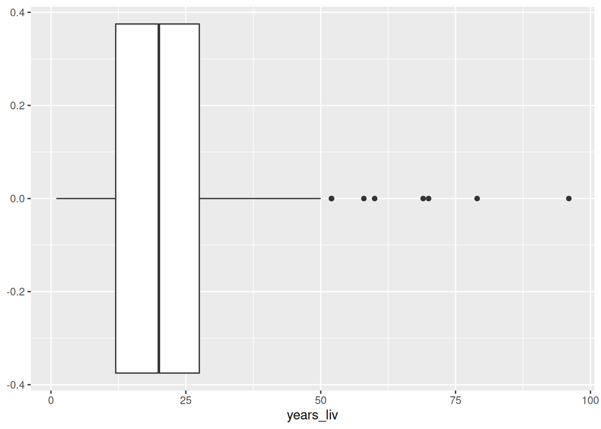

```r
# years_liv cleaning
raw_data_hh%>%
  ggplot(aes(x = years_liv)) +
  geom_boxplot()
```

Anything higher than 90 years seems unlikely, so we set those to NA:

```r
years_liv_clean <-
  raw_data_hh %>%
  select(key_ID, years_liv) %>%
  mutate(years_liv = if_else(years_liv > 90, NA, years_liv))
```

## items_owned

We generate dummies based on the seet items_owned variable:

```r
items_owned <-
  raw_data_hh %>%
  select(key_ID, items_owned) %>%
  filter(!is.na(items_owned)) %>% # non-answers are considered missing
  separate_longer_delim(items_owned, delim = ";") %>%
  mutate(value = 1) %>%
  pivot_wider(names_from = items_owned,
              values_from = value,
              names_glue = "owns_{items_owned}",
              values_fill = 0) %>%
  select(key_ID, starts_with("owns_"))
```

Note that we set non-answers to missing by filtering them out (leading to NAs in the final merged dataset), because we assume this is because the questions is skipped, but we can’t be sure (this is why there should always be a ‘none’ option in such questions!).

## househod roster

We reshape the household roster to wide format:

```r
# individual level
clean_data_individual <-
  raw_data_individual %>%
  mutate(age = if_else(age == -99,NA,age))  %>%
    pivot_wider(names_from = member_ID,
                values_from = !ends_with("_ID"),
                names_vary = "slowest")
```

And we compute some summary statistics at the household level:

```r
household_size <-
  raw_data_individual %>%
  group_by(key_ID) %>%
  mutate(age = if_else(age == -99,NA,age)) %>%
  summarize(hh_size = n(), num_women = sum(female), mean_age = mean(age, na.rm = TRUE))
```

## conflict

```r
conflict <-
  raw_data_hh %>%
  mutate(conflict_yn = case_when(affect_conflicts == "frequently" ~ 1,
                                 affect_conflicts == "more_once" ~ 1,
                                 affect_conflicts == "once" ~ 1,
                                 affect_conflicts == "never" ~ 0,
                                 .default = NA)) %>%
  select(key_ID, conflict_yn)
```

# join and save

We join all clenaed ojects together, and save it in the clean data folder:

```r
clean_data <-
  paradata %>%
  left_join(housing) %>%
  left_join(years_liv_clean) %>%
  left_join(clean_data_individual) %>%
  left_join(household_size) %>%
  left_join(items_owned) %>%
  left_join(conflict)
# saving clean data for later use
clean_data %>% saveRDS(here("data/clean/SAFI_cleaner.rds"))
```